# Assignment 1

Lucian Scher

2026-04-07

In this report we query the New York Times Article Search API for dam removal over the last two years save the results, and summarize coverage over time. We plot how many matching articles appear per day, then tokenize article snippets to examine word frequencies. We remove common stop words and apply several text-cleaning steps so more informative terms stand out. We repeat the frequency analysis using headlines instead of snippets, and we compare the two word-frequency distributions to interpret how titles differ from short excerpts.

### API Function

```r
nytAPI <- function(term1, begin_date, end_date, api) {
  searchQ <- URLencode(term1)
  url <- paste0(
    "https://api.nytimes.com/svc/search/v2/articlesearch.json?q=", searchQ,
    "&begin_date=", begin_date, "&end_date=", end_date, "&api-key=", api
  )
  initialsearch <- fromJSON(url, flatten = TRUE)
  hits <- initialsearch$response$meta$hits
  if (hits == 0) return(data.frame())
  maxPages <- min(round(hits / 10) - 1, 10)
  df <- data.frame(
    id = as.numeric(),
    created_time = character(),
    snippet = character(),
    headline = character()
  )
  for (i in 0:maxPages) {
    nytSearch <- fromJSON(paste0(url, "&page=", i), flatten = TRUE)
    temp <- data.frame(
      id = 1:nrow(nytSearch$response$docs),
      created_time = nytSearch$response$docs$pub_date,
      snippet = nytSearch$response$docs$snippet,
      headline = nytSearch$response$docs$headline.main
    )
    df <- rbind(df, temp)
    Sys.sleep(12)
  }
  return(df)
}
```

### Fetch from API and save CSV

```r
# Fetch results using API function
nytDat <- nytAPI(
  term1 = "dam removal",
  begin_date = "20240401",
  end_date = "20260401",
  api = API_KEY
)

write.csv(nytDat, "NYT-dam_removal.csv", row.names = FALSE)
```

### Publications per day

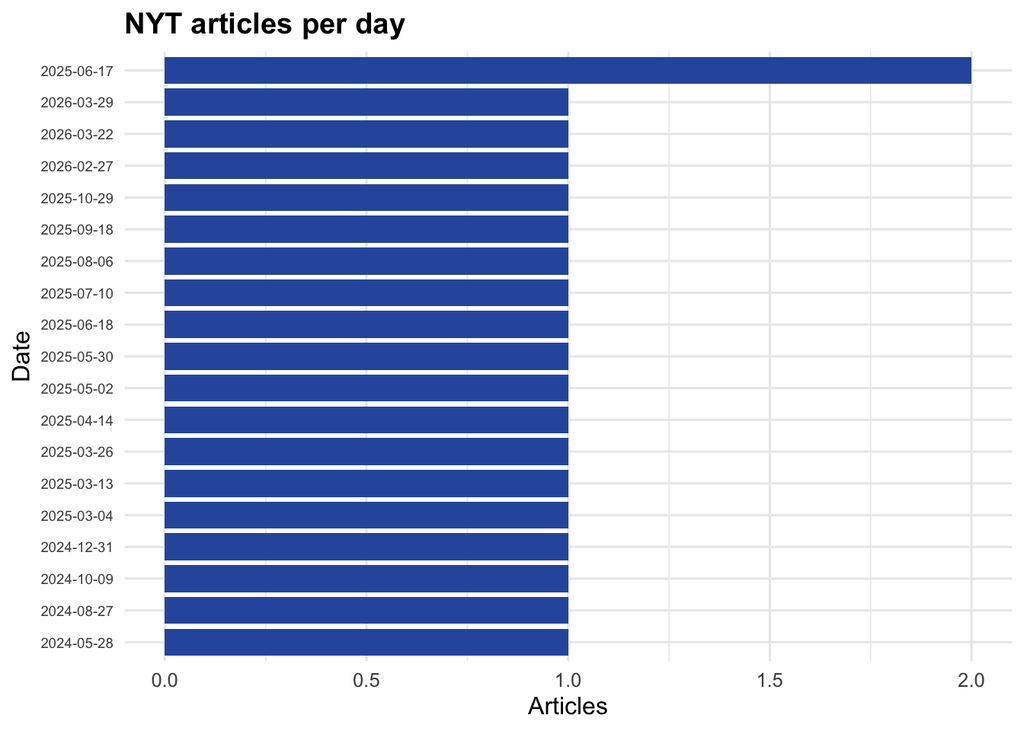

```r
# One row per article: aggregate to counts per calendar day; keep busy days only (lab-style filter).
daily_counts <- nytDat %>%
  mutate(pubDay = as.Date(created_time)) %>%
  count(pubDay, name = "count") #%>%
  #filter(count >= 2)

ggplot(daily_counts, aes(x = reorder(pubDay, count), y = count)) +
  geom_col(fill = "#2E5AAC", width = 0.85) +
  coord_flip() +
  labs(
    title = "NYT articles per day",
    x = "Date",
    y = "Articles"
  ) +
  theme_minimal(base_size = 12) +
  theme(plot.title = element_text(face = "bold"), axis.text.y = element_text(size = 7))
```

### Snippets: tokenize and plot frequencies

```r
# One token per row; lowercase and punctuation handled by unnest_tokens().
tokenized <- nytDat %>%
  unnest_tokens(word, snippet)
```

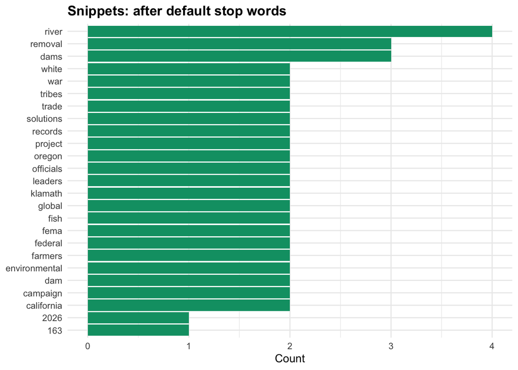

```r
data("stop_words")
tokenized <- tokenized %>%
  anti_join(stop_words, by = "word")

snippet_freq_stop <- tokenized %>% count(word, sort = TRUE)
ggplot(snippet_freq_stop %>% slice_head(n = 25), aes(x = reorder(word, n), y = n)) +
  geom_col(fill = "#009E73") +
  coord_flip() +
  labs(title = "Snippets: after default stop words", x = NULL, y = "Count") +
  theme_minimal() +
  theme(plot.title = element_text(face = "bold"))
```